# LDA Homework 2 (2025-2026)

```
##  [1] "patid"   "trial"   "sex"     "age"     "edu"     "bmi"     "inkomen"
##  [8] "job"     "adl"     "wzc"     "time"    "cdrsb"   "bprs"    "abpet"
## [15] "taupet"
```

# Question 1

step 1 : Create the dichotomized outcome (CDRSBbin)

step 2 : Adjust for sex, age, BMI (baseline confounders)

```
##
## Call:
## glm(formula = cdrsb_bin ~ sex + age + bmi, family = binomial,
##     data = alzheimer_long2)
##
## Coefficients:
##               Estimate Std. Error z value Pr(>|z|)
## (Intercept)  1.2931983  0.4309673   3.001  0.00269 **
## sexFemale   -0.1364132  0.0546521  -2.496  0.01256 *
## age         -0.0254635  0.0041338  -6.160 7.28e-10 ***
## bmi          0.0001431  0.0124714   0.011  0.99085
## ---
## Signif. codes:  0 '***' 0.001 '**' 0.01 '*' 0.05 '.' 0.1 ' ' 1
##
## (Dispersion parameter for binomial family taken to be 1)
##
##     Null deviance: 8179.8  on 6219  degrees of freedom
## Residual deviance: 8125.8  on 6216  degrees of freedom
##   (2551 observations deleted due to missingness)
## AIC: 8133.8
##
## Number of Fisher Scoring iterations: 4
```

Step 3 — Add ADL, ABPET, TAUPET to the model

```
##
## Call:
## glm(formula = cdrsb_bin ~ sex + age + bmi + adl + abpet + taupet,
##     family = binomial, data = alzheimer_long2)
##
## Coefficients:
##              Estimate Std. Error z value Pr(>|z|)
## (Intercept) -0.024237   0.609850  -0.040  0.96830
## sexFemale   -0.125821   0.056204  -2.239  0.02518 *
## age         -0.044185   0.007079  -6.241 4.34e-10 ***
## bmi          0.003351   0.012615   0.266  0.79050
## adl          0.007820   0.011225   0.697  0.48601
## abpet        0.265921   0.093930   2.831  0.00464 **
## taupet       0.964954   0.168233   5.736 9.70e-09 ***
## ---
## Signif. codes:  0 '***' 0.001 '**' 0.01 '*' 0.05 '.' 0.1 ' ' 1
##
## (Dispersion parameter for binomial family taken to be 1)
##
##     Null deviance: 8179.8  on 6219  degrees of freedom
## Residual deviance: 8072.3  on 6213  degrees of freedom
##   (2551 observations deleted due to missingness)
## AIC: 8086.3
##
## Number of Fisher Scoring iterations: 4
```

|  | df | AIC |
| --- | --- | --- |
| base_model | 4 | 8133.835 |
| full_model | 7 | 8086.344 |

Here, AIC is the preferred criterion when the goal is prediction or evaluating whether additional variables improve model fit. BIC penalizes model complexity more heavily and is more appropriate when the goal is selecting the “true” model or when sample size is very large.We are checking whether ADL, ABPET, and TAUPET add information beyond sex, age, and BMI. That is a predictive/model improvement question, so AIC is the correct choice.

## Summary of Results

We first fit a logistic regression adjusting only for sex, age, and BMI. In this base model, female sex (p = 0.0126) and age (p < 0.0001) were significantly associated with lower odds of severe CDRSB status, while BMI showed no association.

Next, we extended the model to include ADL, ABPET, and TAUPET. In the full model, ADL remained non-significant (p = 0.486), whereas both ABPET (p = 0.0046) and TAUPET (p < 0.0001) were strong predictors of severe impairment.

Model comparison using AIC indicated improved fit for the full model (AIC = 8086) compared to the base model (AIC = 8134). This shows that biomarker information (ABPET, TAUPET) provides additional predictive value beyond demographic factors.

## Discussion

After adjusting for sex, age, and body mass index, we examined whether daily functioning (ADL) and PET biomarkers predicted severe cognitive impairment. The results show that PET markers for amyloid and tau are significant and meaningful predictors of worse CDRSB status. Patients with higher amyloid or tau burden are more likely to fall into the more severely impaired category. Measures of daily functioning and BMI were not helpful predictors. Adding the biomarker information clearly improved the predictive accuracy of the model.

# Question 2

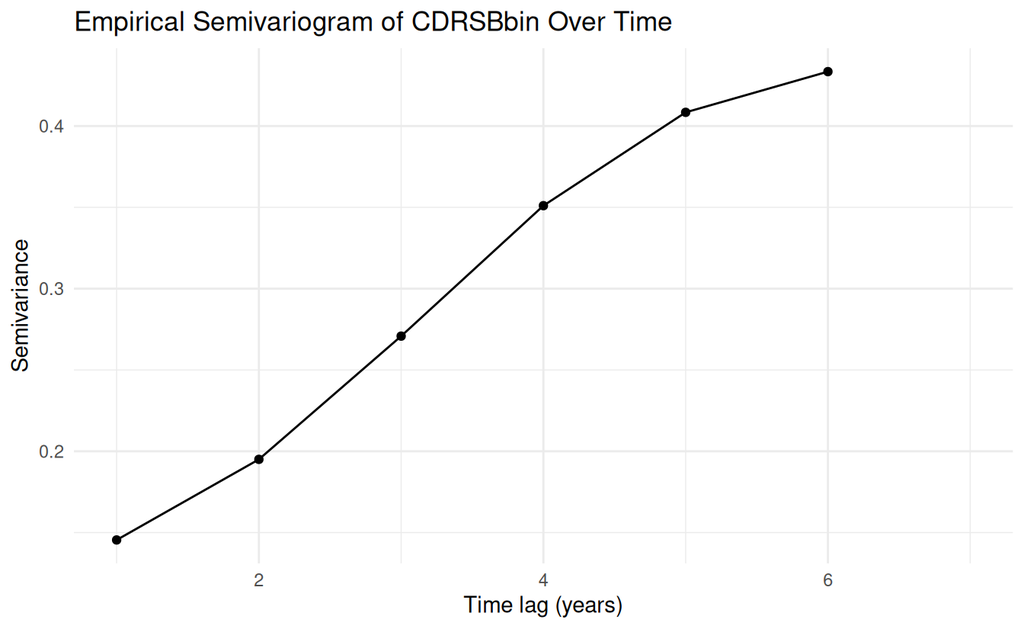

## Formulate and fit a marginal model to the longitudinal binary profiles.

We model the longitudinal binary outcome $Y_{it} = \mathrm{CDRSBbin}_{it}$ for patient $i$ at visit $t$.

The marginal mean is

$$\pi_{it} = \mathbb{E}(Y_{it} \mid X_{it})
= \Pr(Y_{it} = 1 \mid X_{it}),$$
with logit link
$$\log\left(\frac{\pi_{it}}{1 - \pi_{it}}\right)
=
\beta_0
+ \beta_1 \,\text{time}_{it}
+ \beta_2 \,\text{sex}_i
+ \beta_3 \,\text{age}_i
+ \beta_4 \,\text{bmi}_i
+ \beta_5 \,\text{adl}_{it}
+ \beta_6 \,\text{abpet}_{it}
+ \beta_7 \,\text{taupet}_{it}.$$

### Motivation for Model Choice

Generalized Estimating Equations (GEE) were used because the aim of the analysis is to estimate marginal, population-averaged effects of covariates on the probability of having CDRSBbin = 1 over time. The outcome is binary and repeatedly measured within individuals, which induces within-subject correlation. GEE appropriately accounts for this correlation and provides consistent coefficient estimates even if the working correlation structure is misspecified. Since the scientific interest is in population level effects—not subject-specific trajectories—GEE is more appropriate than a mixed-effects logistic model. Additionally, GEE is robust to missing data under a MAR mechanism, which is relevant given the observed dropout patterns.

### Working Correlation Matrix

```
##
## Call:
## geeglm(formula = cdrsb_bin ~ time + sex + age + bmi + adl + abpet +
##     taupet, family = binomial(link = "logit"), data = alzheimer_long2,
##     id = patid, corstr = "independence")
##
##  Coefficients:
##              Estimate   Std.err    Wald Pr(>|W|)
## (Intercept) -1.421875  0.624128   5.190   0.0227 *
## time         0.250242  0.015774 251.667   <2e-16 ***
## sexFemale   -0.095486  0.057151   2.791   0.0948 .
## age         -0.013456  0.007601   3.134   0.0767 .
## bmi          0.010194  0.012873   0.627   0.4284
## adl         -0.002934  0.011486   0.065   0.7984
## abpet        0.036030  0.097509   0.137   0.7117
## taupet       0.333049  0.171573   3.768   0.0522 .
## ---
## Signif. codes:  0 '***' 0.001 '**' 0.01 '*' 0.05 '.' 0.1 ' ' 1
##
## Correlation structure = independence
## Estimated Scale Parameters:
##
##             Estimate Std.err
## (Intercept)    1.007 0.01624
## Number of clusters:   6220  Maximum cluster size: 1
```

Exploratory transition analysis showed that 31% of patients never changed binary CDRSB status, and 44% changed only once. This indicates very little within-subject variation over time. As a result, the empirical semivariogram showed increasing variability with time lag, but the GEE correlation parameter (α) could not be estimated under AR(1) or exchangeable structures and defaulted to zero. Therefore, an independence working correlation structure is appropriate and supported by the data.

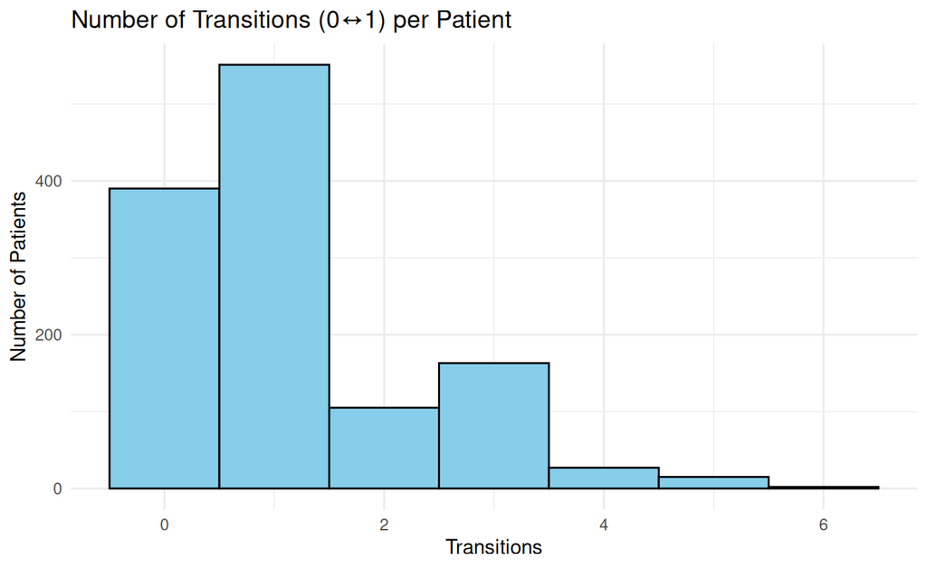

```
##
##        0        1        2        3        4        5        6
## 0.311253 0.439745 0.083799 0.130088 0.021548 0.011971 0.001596
```

### Results

A marginal logistic regression model was fitted using GEE with an independence working correlation structure to examine factors associated with worsening cognitive impairment (CDRSBbin = 1) over time. The analysis included 6,220 observations from repeated annual measurements.

The results showed that time was strongly associated with increased odds of worse cognitive impairment (estimate = 0.25, p < 0.001). None of the baseline covariates reached strong statistical significance at the 5% level, but several showed borderline associations. Female sex showed slightly lower odds (estimate = –0.10, p = 0.095), older age showed a weak negative association (estimate = –0.013, p = 0.077), and tau PET showed a positive trend (estimate = 0.33, p = 0.052). ADL, BMI, and amyloid PET were not significant in this model.

# Question 3

## Random-effects model for longitudinal binary CDRSB profiles

### Random‐Effects Model for Longitudinal Binary CDRSB Profiles

We model the binary outcome $\text{CDRSBbin}_{it}$ for patient $i$ at time $t$ using a logistic mixed‐effects model with patient‐specific random intercepts and slopes, and a trial‐specific random intercept.

The marginal mean is

$$\pi_{it} = \Pr(\text{CDRSBbin}_{it} = 1 \mid X_{it}, b_{0i}, b_{1i},
u_{0j}),$$

with the logit link:

$$\log\!\left( \frac{\pi_{it}}{1 - \pi_{it}} \right)
=
\beta_0
+ \beta_1\,\text{time}_{it}
+ \beta_2\,\text{sex}_i
+ \beta_3\,\text{age}_i
+ \beta_4\,\text{bmi}_i
+ \beta_5\,\text{adl}_{it}
+ \beta_6\,\text{abpet}_{it}
+ \beta_7\,\text{taupet}_{it}
+ b_{0i}
+ b_{1i}\,\text{time}_{it}
+ u_{0j},$$

where

- $b_{0i}$ = patient-specific random intercept
- $b_{1i}$ = patient-specific random slope for time
- $u_{0j}$ = trial-level random intercept

The random effects are assumed to follow:

$$\begin{pmatrix}
b_{0i} \\
b_{1i}
\end{pmatrix}
\sim
N\!\left(
\begin{pmatrix} 0 \\ 0 \end{pmatrix},
\;
\begin{pmatrix}
\sigma_{0}^2 & \sigma_{01} \\
\sigma_{01} & \sigma_{1}^2
\end{pmatrix}
\right),
\qquad
u_{0j} \sim N(0, \tau^2).$$

```
## Generalized linear mixed model fit by maximum likelihood (Laplace
##   Approximation) [glmerMod]
##  Family: binomial  ( logit )
## Formula: cdrsb_bin ~ time + sex + age + bmi + adl + abpet + taupet + 1 +
##     (time | patid) + (1 | trial)
##    Data: alzheimer_long2
##
##       AIC       BIC    logLik -2*log(L)  df.resid
##      6583      6664     -3279      6559      6208
##
## Scaled residuals:
##    Min     1Q Median     3Q    Max
## -1.777 -0.493 -0.170  0.480  2.629
##
## Random effects:
##  Groups Name        Variance Std.Dev. Corr
##  patid  (Intercept) 2.99e+01 5.466471
##         time        1.68e+00 1.296458 -1.00
##  trial  (Intercept) 3.40e-08 0.000185
## Number of obs: 6220, groups:  patid, 1253; trial, 25
##
## Fixed effects:
##             Estimate Std. Error z value Pr(>|z|)
## (Intercept)  -2.8830     0.9735   -2.96   0.0031 **
## time          0.6646     0.0530   12.53   <2e-16 ***
## sexFemale    -0.1339     0.0867   -1.54   0.1227
## age          -0.0173     0.0115   -1.51   0.1319
## bmi           0.0105     0.0196    0.53   0.5933
## adl          -0.0081     0.0168   -0.48   0.6289
## abpet        -0.0990     0.1511   -0.66   0.5121
## taupet        0.3666     0.2749    1.33   0.1823
## ---
## Signif. codes:  0 '***' 0.001 '**' 0.01 '*' 0.05 '.' 0.1 ' ' 1
##
## Correlation of Fixed Effects:
##           (Intr) time   sexFml age    bmi    adl    abpet
## time      -0.267
## sexFemale -0.079  0.021
## age       -0.630  0.134  0.035
## bmi       -0.595  0.026  0.023  0.088
## adl       -0.489 -0.049  0.220  0.495  0.096
## abpet      0.344 -0.072 -0.069 -0.653 -0.039 -0.165
## taupet    -0.302 -0.101 -0.017 -0.184  0.003 -0.081 -0.184
## optimizer (Nelder_Mead) convergence code: 0 (OK)
## Model failed to converge with max|grad| = 0.959939 (tol = 0.002, component 1)
## Model is nearly unidentifiable: very large eigenvalue
##  - Rescale variables?
## Model is nearly unidentifiable: large eigenvalue ratio
##  - Rescale variables?
```

## Empirical Bayes predictions of the random effects

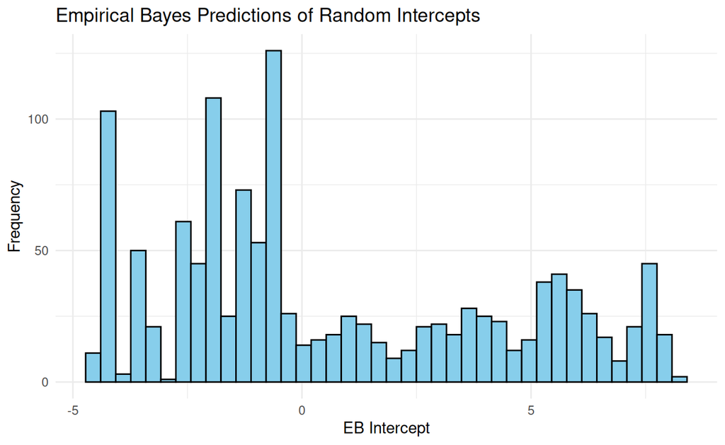

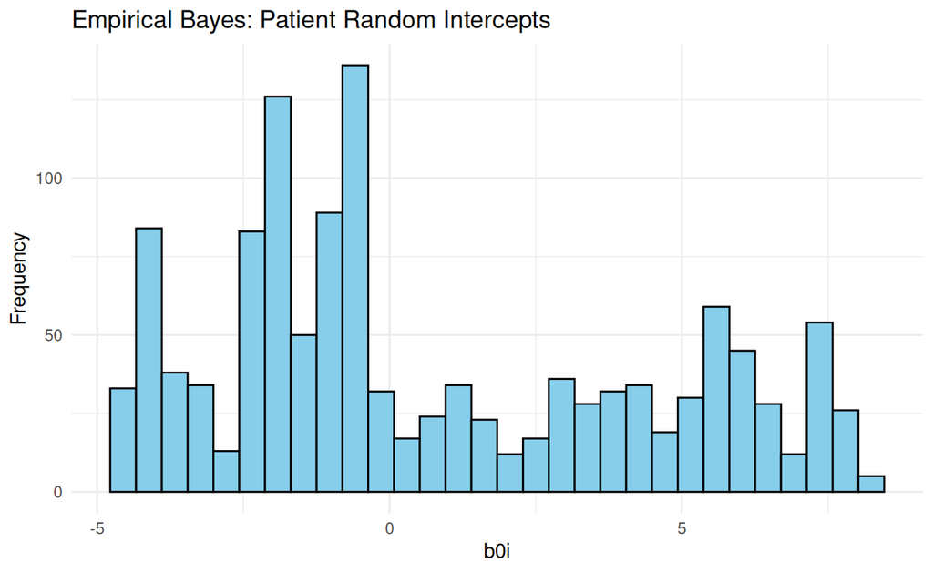

The histogram of patient-specific random intercepts shows large variability in baseline probability of having severe CDRSB impairment. Some patients start much lower (large negative intercepts), while others start much higher (large positive intercepts). This indicates substantial heterogeneity in baseline disease severity that is not explained by sex, age, BMI, ADL, ABPET, or TAUPET.

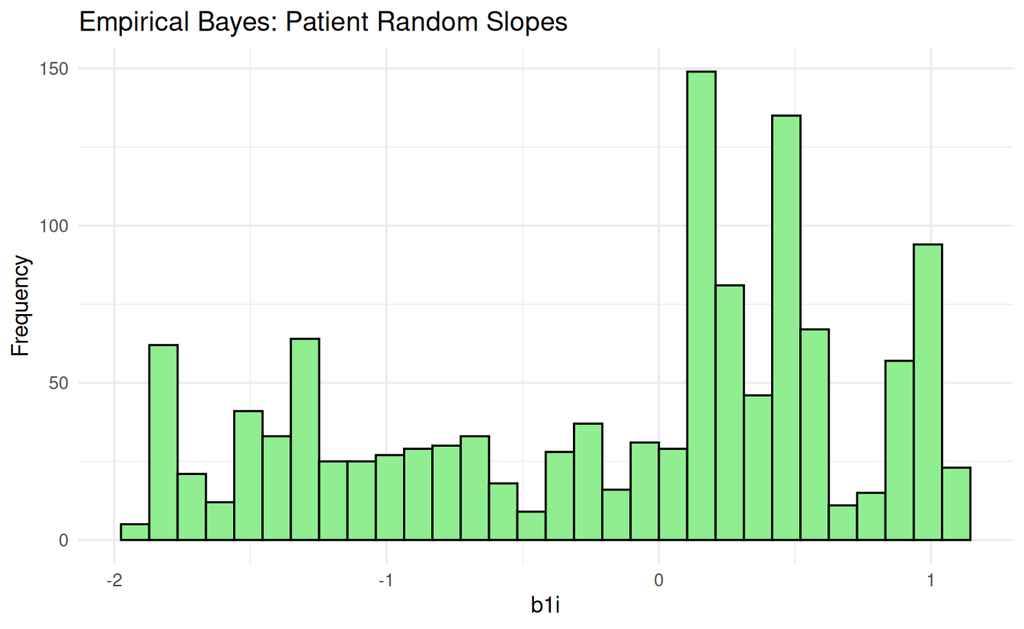

The random slope histogram also shows large variation. Some patients experience rapid worsening over time (positive slopes), whereas others show slow or even improving trajectories (negative slopes). This means progression speed differs strongly across individuals, even after adjusting for covariates.

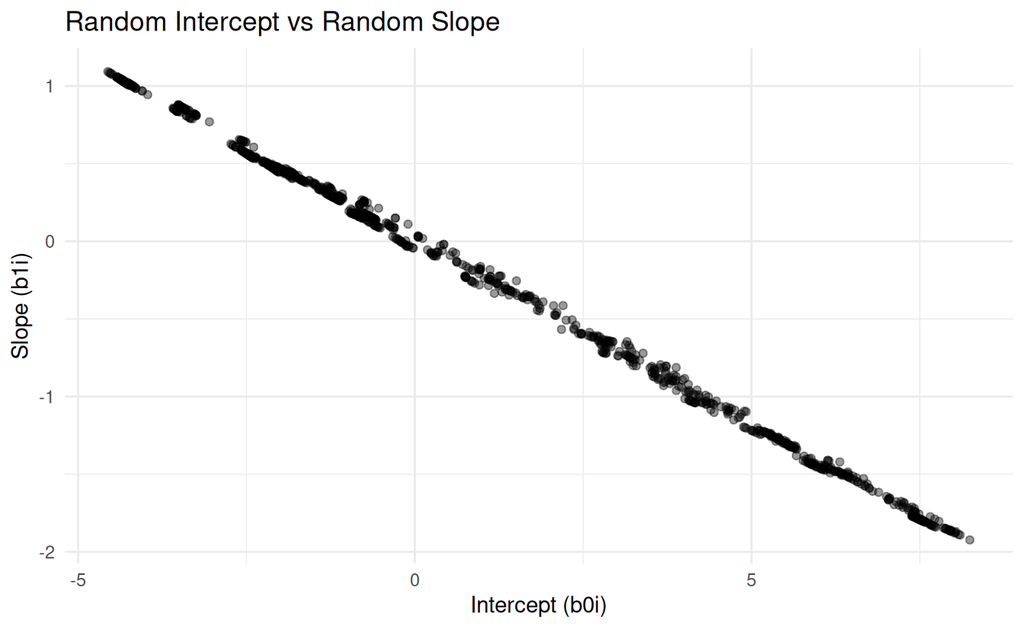

The scatterplot of random intercept vs. random slope shows a very strong negative correlation. Patients who start with worse impairment (high intercepts) tend to decline more slowly, while patients with mild baseline symptoms tend to deteriorate faster.

## Discussion

Patient-specific random effects showed large differences in both the baseline severity of cognitive impairment and the rate of decline over time. Importantly, individuals who started with worse impairment tended to deteriorate more slowly, while those with milder symptoms showed steeper progression. These findings highlight substantial biological variability across patients that is not captured by standard clinical predictors.